# Task

## 2.

For the selected protected attribute (age, gender, race) calculate the following fairness coefficients: Statistical parity, Equal opportunity, Predictive parity.

**I calculated statistics with respect to the age ("old" if larger than 50 and "young" otherwise).**

The privileged group is the elderly.

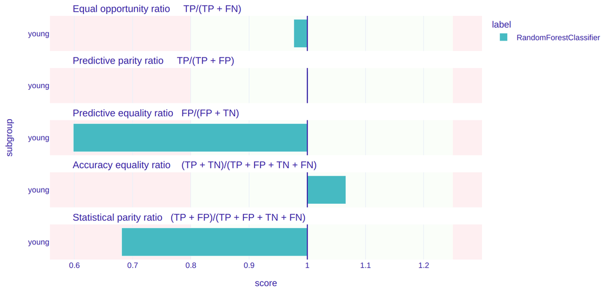

The model is biased against young people. It would less likely predict that a young person earns a lot.

## 3.

Train another model (different hyperparameters, feature transformations etc.) and see how the coefficients Statistical parity, Equal opportunity, Predictive parity behave for it.

**Shallow Random Forest Classifier with max depth equal 5**

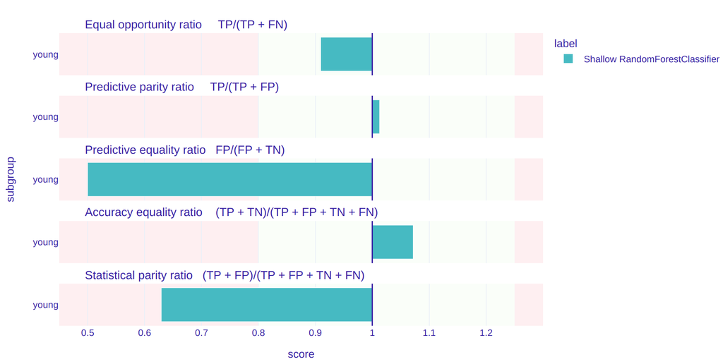

Equal opportunity ratio and Predictive equality ratio are a little bit more biased for the shallow Random Forest Classifier.

## 4.

Apply the selected bias mitigation technique on the first model. Check how Statistical parity, Equal opportunity, Predictive parity coefficients behave after this correction.

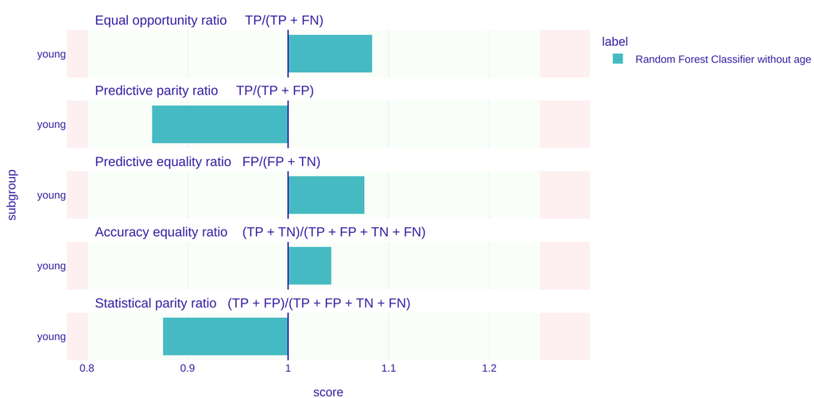

Now the model is not biased against any group.

## 5.

Compare the quality (performance) of the three models with their fairness coefficients. Is there any correlation?

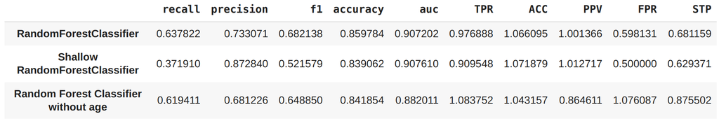

Shallow Random Forest Classifier has the worst performance and is also the most biased. On the other hand, two other models have similar performance, but one is biased and one is not.

# Appendix

```python
#@title Imports
import dalex as dx
from dalex.fairness import roc_pivot

from copy import deepcopy
import matplotlib.pyplot as plt
import sklearn
import pandas as pd
import numpy as np

from sklearn.ensemble import RandomForestClassifier
from sklearn.model_selection import train_test_split

import warnings
warnings.filterwarnings("ignore")
```

## Data download

```python
from google.colab import drive
drive.mount('/content/drive')
```

```python
df = pd.read_csv("/content/adult.csv.zip").dropna()
df
```

|  | age | workclass | fnlwgt | education | educational-num | marital-status | occupation | relationship | race | gender | capital-gain | capital-loss | hours-per-week | native-country | income |
| --- | --- | --- | --- | --- | --- | --- | --- | --- | --- | --- | --- | --- | --- | --- | --- |
| 0 | 25 | Private | 226802 | 11th | 7 | Never-married | Machine-op-inspct | Own-child | Black | Male | 0 | 0 | 40 | United-States | <=50K |
| 1 | 38 | Private | 89814 | HS-grad | 9 | Married-civ-spouse | Farming-fishing | Husband | White | Male | 0 | 0 | 50 | United-States | <=50K |
| 2 | 28 | Local-gov | 336951 | Assoc-acdm | 12 | Married-civ-spouse | Protective-serv | Husband | White | Male | 0 | 0 | 40 | United-States | >50K |
| 3 | 44 | Private | 160323 | Some-college | 10 | Married-civ-spouse | Machine-op-inspct | Husband | Black | Male | 7688 | 0 | 40 | United-States | >50K |
| 4 | 18 | ? | 103497 | Some-college | 10 | Never-married | ? | Own-child | White | Female | 0 | 0 | 30 | United-States | <=50K |
| ... | ... | ... | ... | ... | ... | ... | ... | ... | ... | ... | ... | ... | ... | ... | ... |
| 48837 | 27 | Private | 257302 | Assoc-acdm | 12 | Married-civ-spouse | Tech-support | Wife | White | Female | 0 | 0 | 38 | United-States | <=50K |
| 48838 | 40 | Private | 154374 | HS-grad | 9 | Married-civ-spouse | Machine-op-inspct | Husband | White | Male | 0 | 0 | 40 | United-States | >50K |
| 48839 | 58 | Private | 151910 | HS-grad | 9 | Widowed | Adm-clerical | Unmarried | White | Female | 0 | 0 | 40 | United-States | <=50K |
| 48840 | 22 | Private | 201490 | HS-grad | 9 | Never-married | Adm-clerical | Own-child | White | Male | 0 | 0 | 20 | United-States | <=50K |
| 48841 | 52 | Self-emp-inc | 287927 | HS-grad | 9 | Married-civ-spouse | Exec-managerial | Wife | White | Female | 15024 | 0 | 40 | United-States | >50K |

48842 rows × 15 columns

## 1.

```python
X = df.drop(columns=['income'])
X = pd.get_dummies(X, columns=["workclass", "education", "marital-status", "occupation", "relationship", "race", "gender", "native-country"], drop_first=True)
y = df['income'] == ">50K"


X_train, X_test, y_train, y_test = train_test_split(X, y, test_size=0.33, random_state=42)
```

```python
rfc_model = RandomForestClassifier()
rfc_model.fit(X_train, y_train)
```

## 2.

```python
def predict_function(model, df):
    df.loc[:, df.dtypes == 'object'] = df.select_dtypes(['object']).apply(lambda x: x.astype('category'))
    return model.predict_proba(df)[:, 1]

rfc_explainer = dx.Explainer(rfc_model, X_test, y_test, predict_function=predict_function)
```

```python
protected = X_test['age'].apply(lambda x: "old" if x > 50 else "young")
privileged = "old"

rfc_fairness = rfc_explainer.model_fairness(protected=protected, privileged=privileged)
```

```python
rfc_fairness.fairness_check()
```

```python
rfc_fairness.plot()
```

## 3.

```python
shallow_rfc_model = RandomForestClassifier(max_depth=5)
shallow_rfc_model.fit(X_train, y_train)
```

```python
explainer_shallow = dx.Explainer(shallow_rfc_model, X_test, y_test, predict_function=predict_function, label="Shallow RandomForestClassifier")
```

```python
shallow_fairness = explainer_shallow.model_fairness(protected=protected, privileged=privileged)
shallow_fairness.fairness_check()
```

```python
shallow_fairness.plot()
```

## 4.

```python
X_train_no_age = X_train.drop(columns=['age'])
X_test_no_age = X_test.drop(columns=['age'])
```

```python
model = RandomForestClassifier()
model.fit(X_train_no_age, y_train)
```

```python
explainer_no_age = dx.Explainer(model, X_test_no_age, y_test, predict_function=predict_function, label="Random Forest Classifier without age")
```

```python
fairness_no_age = explainer_no_age.model_fairness(protected=protected, privileged=privileged)
```

```python
explainer_roc_pivot = roc_pivot(deepcopy(explainer_no_age), protected, privileged, verbose=False)
fairness = explainer_roc_pivot.model_fairness(protected, privileged)
fairness.fairness_check()
```

```python
fairness.plot()
```

## 5.

```python
_df = pd.concat([rfc_explainer.model_performance().result, explainer_shallow.model_performance().result, explainer_no_age.model_performance().result])
```

```python
fairness1 = pd.DataFrame(rfc_fairness.result[["TPR", "ACC", "PPV", "FPR", "STP"]].loc["young"]).T
fairness1.index = ['RandomForestClassifier']
fairness2 = pd.DataFrame(shallow_fairness.result[["TPR", "ACC", "PPV", "FPR", "STP"]].loc["young"]).T
fairness2.index = ['Shallow RandomForestClassifier']
fairness3 = pd.DataFrame(fairness.result[["TPR", "ACC", "PPV", "FPR", "STP"]].loc["young"]).T
fairness3.index = ['Random Forest Classifier without age']
df_fairness = pd.concat([fairness1, fairness2, fairness3])
```

```python
_df.join(df_fairness)
```